# act_report

## Report: act_report

- Create a **250-word-minimum written report** called "act_report.pdf" or "act_report.html" that communicates the insights and displays the visualization(s) produced from your wrangled data. This is to be framed as an external document, like a blog post or magazine article, for example.

Reported by Mahshid Kalantari

Insights

1. Top-rated dogs: To find the top_rated dogs, I used the value_count method to assess the rating_numerator that equals 14. It indicated the breeds that have the highest rating. The first top-rated dog is “Pembroke”.
2. Most dog breeds: In the next step, I tried to understand the most common breed with the highest prediction that was already gathered in the breed column. The first one was “golden_retriever”.
3. Top common name for dogs: For the top common name for the dogs, I analyzed the name column. The most common name was “Cooper”.
4. Top favorite dogs: I could find the top favorite breed dogs from the favorite_count column with groupby and sum and sorted_value methods and the first one was “golden_retriever”.
5. Top retweeted dogs: I repeated the last step for the retweet_count to find the top breed dogs in this category. I found the four top-breed dogs were the same as the ones in the favorite_count column.
6. Top stages of dogs: the last insight was related to finding the top stages of dogs in the retweet_count column and the first top stage was “pupper”.

Visualization

1. For comparing the mean of favorite_count and the mean of retweet_count between different stages of dogs, I made a bar chart that had the dog stage on the x-axis and the number of favorite and retweet counts on the y-axis. As seen, the highest number belonged to “doggo, puppo” stage, and the lowest was related to “pupper” stage.

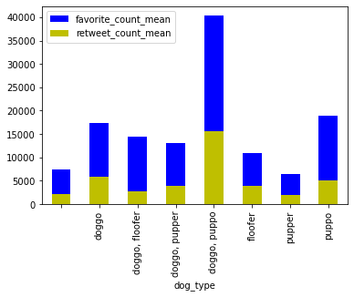